# apple

2025-03-02

#APPLE QUALITY CLASSIFIER USING R

There are 4,001 entries in the Apple Quality Data set taken from Kaggle, and each one describes a different feature of a single apple. The dataset comprises several key attributes:

A_id (Apple ID): Each apple’s unique identifier. Size: Reflects the physical dimensions or volume. Weight: Mass of each apple, typically measured in grams. Quality Attributes: Sweetness: Based on sugar content. Crunchiness: Assessed via mechanical testing. Juiciness: Evaluated by juice yield. Ripeness: Determined through firmness or biochemical markers. Acidity: Acid content affecting flavor. Quality: Overall quality classification into ‘good’ or ‘bad’.

## Importing libraries

The machine learning models in R, we use the caret package. ggplot2 and gridExtra are used for creating plot and data visualizations. corrplot is for correlation plots

To install any package install.packages(“package_name”)

```r
library(caret)
library(dplyr)
library(ggplot2)
library(gridExtra)
library(corrplot)
library(ClusterR)
library(cluster)
library(clue)
library(class)
library(factoextra)
library(tidyverse)
library(pROC)
library(rpart)  # For CART
library(randomForest)
```

## Uploading dataset

The data set is an open-source data set taken from kaggle https://www.kaggle.com/datasets/nelgiriyewithana/apple-quality. Here, we have manually downloaded the data set and uploaded it using read.csv.You can replace “your_dataset_location.csv” with the actual path to your data set file.

```r
apple_quality <- read.csv("/cloud/project/apple_quality.csv")
apple_quality
```

```
##     A_id        Size       Weight   Sweetness Crunchiness   Juiciness    Ripeness      Acidity Quality
## 1      0 -3.97004852 -2.512336381  5.34632961 -1.01200871  1.84490036  0.32983980 -0.491590483    good
## 2      1 -1.19521719 -2.839256528  3.66405876  1.58823231  0.85328580  0.86753008 -0.722809367    good
## 3      2 -0.29202386 -1.351281995 -1.73842916 -0.34261593  2.83863551 -0.03803333  2.621636473     bad
## 4      3 -0.65719577 -2.271626609  1.32487385 -0.09787472  3.63797049 -3.41376134  0.790723217    good
## 5      4  1.36421682 -1.296611877 -0.38465821 -0.55300577  3.03087435 -1.30384943  0.501984036    good
## 6      5 -3.42539975 -1.409082204 -1.91351120 -0.55577486 -3.85307147  1.91461592 -2.981523169     bad
## 7      6  1.33160574  1.635955715  0.87597424 -1.67779794  3.10634445 -1.84741673  2.414170509    good
## 8      7 -1.99546210 -0.428958480  1.53064358 -0.74297168  0.15883400  0.97443786 -1.470125066    good
## 9      8 -3.86763223 -3.734513576  0.98642907 -1.20765455  2.29287292  4.08092079 -4.871904758     bad
## 10     9 -0.72798271 -0.442820353 -4.09222283  0.59751292  0.39371426  1.62085677  2.185607723     bad
## 11    10 -2.69933629 -1.329506988 -1.41850685 -0.62554577  2.37107437  3.40316452 -2.810808169     bad
## 12    11  2.45095984 -0.564177407 -1.63504073  0.94239987 -2.08731667  1.21432169  1.294323927    good
## 13    12 -0.17081172 -1.867271142 -1.77184473  2.41315532 -3.09455474 -0.62488438 -2.076113997     bad
## 14    13 -1.34553054 -1.623701121  2.04414375  1.75481293  0.99756709  0.43417986  1.724026084    good
```

[output cut: 98 more lines]

##3.Exploratory Data Analysis Let’s do some data analysis on out apple quality data set that we have.

First,let’s us see the summary of out dataset.

```r
summary(apple_quality)
```

```
##       A_id             Size             Weight           Sweetness        Crunchiness         Juiciness
##  Min.   :   0.0   Min.   :-7.1517   Min.   :-7.14985   Min.   :-6.8945   Min.   :-6.05506   Min.   :-5.9619
##  1st Qu.: 999.8   1st Qu.:-1.8168   1st Qu.:-2.01177   1st Qu.:-1.7384   1st Qu.: 0.06276   1st Qu.:-0.8013
##  Median :1999.5   Median :-0.5137   Median :-0.98474   Median :-0.5048   Median : 0.99825   Median : 0.5342
##  Mean   :1999.5   Mean   :-0.5030   Mean   :-0.98955   Mean   :-0.4705   Mean   : 0.98548   Mean   : 0.5121
##  3rd Qu.:2999.2   3rd Qu.: 0.8055   3rd Qu.: 0.03098   3rd Qu.: 0.8019   3rd Qu.: 1.89423   3rd Qu.: 1.8360
##  Max.   :3999.0   Max.   : 6.4064   Max.   : 5.79071   Max.   : 6.3749   Max.   : 7.61985   Max.   : 7.3644
##  NA's   :1        NA's   :1         NA's   :1          NA's   :1         NA's   :1          NA's   :1
##     Ripeness         Acidity            Quality
##  Min.   :-5.8646   Length:4001        Length:4001
##  1st Qu.:-0.7717   Class :character   Class :character
##  Median : 0.5034   Mode  :character   Mode  :character
##  Mean   : 0.4983
##  3rd Qu.: 1.7662
##  Max.   : 7.2378
##  NA's   :1
```

```r
col_values <- sapply(apple_quality, function(x) length(x))
print(col_values)
```

```
##        A_id        Size      Weight   Sweetness Crunchiness   Juiciness    Ripeness     Acidity     Quality
##        4001        4001        4001        4001        4001        4001        4001        4001        4001
```

To check the total number of values in each column,So, we can conclude that each column has same number of values but we also need to check if there are any missing values in each columns.

```r
missing_values <- colSums(is.na(apple_quality))
missing_values
```

```
##        A_id        Size      Weight   Sweetness Crunchiness   Juiciness    Ripeness     Acidity     Quality
##           1           1           1           1           1           1           1           0           0
```

There is 1 missing value.

```r
apple_quality <- na.omit(apple_quality)
missing_values <- colSums(is.na(apple_quality))
print(missing_values)
```

```
##        A_id        Size      Weight   Sweetness Crunchiness   Juiciness    Ripeness     Acidity     Quality
##           0           0           0           0           0           0           0           0           0
```

We can see the last row of the dataset is not helpful for us as it just contains the details of author of the data set. So, we can drop the last row and also we check the missing values again after removing the rows.

```r
duplicated_rows <- duplicated(apple_quality)

# Count the total number of duplicate rows
total_duplicates <- sum(duplicated_rows)

# Print the count of duplicate rows
print(total_duplicates)
```

```
## [1] 0
```

We can also remove column A_id as it does not add any valuable information.

```r
apple_quality <- apple_quality[, !(names(apple_quality) == "A_id")]
head(apple_quality)
```

```
##         Size    Weight  Sweetness Crunchiness  Juiciness    Ripeness      Acidity Quality
## 1 -3.9700485 -2.512336  5.3463296 -1.01200871  1.8449004  0.32983980 -0.491590483    good
## 2 -1.1952172 -2.839257  3.6640588  1.58823231  0.8532858  0.86753008 -0.722809367    good
## 3 -0.2920239 -1.351282 -1.7384292 -0.34261593  2.8386355 -0.03803333  2.621636473     bad
## 4 -0.6571958 -2.271627  1.3248738 -0.09787472  3.6379705 -3.41376134  0.790723217    good
## 5  1.3642168 -1.296612 -0.3846582 -0.55300577  3.0308744 -1.30384943  0.501984036    good
## 6 -3.4253998 -1.409082 -1.9135112 -0.55577486 -3.8530715  1.91461592 -2.981523169     bad
```

We can see the datatypes of each column and the values of column Acidity is in double but the datatype of Acidity is in character. So we can convert the datatype of Acidity to double. We also check for any missing values after our type conversion.

```r
# converting type of Acidity to double
apple_quality$Acidity <- as.numeric(apple_quality$Acidity)
print(typeof(apple_quality$Acidity))
```

```
## [1] "double"
```

```r
# Checking if there are any missing values in each columns
missing_values <- colSums(is.na(apple_quality))
print(missing_values)
```

```
##        Size      Weight   Sweetness Crunchiness   Juiciness    Ripeness     Acidity     Quality
##           0           0           0           0           0           0           0           0
```

##Analyzing values in each feature First let us convert the column Quality from character to binary like giving values to GOOD = 1 and BAD = 0. Converting it to binary will be useful for further data analysis.

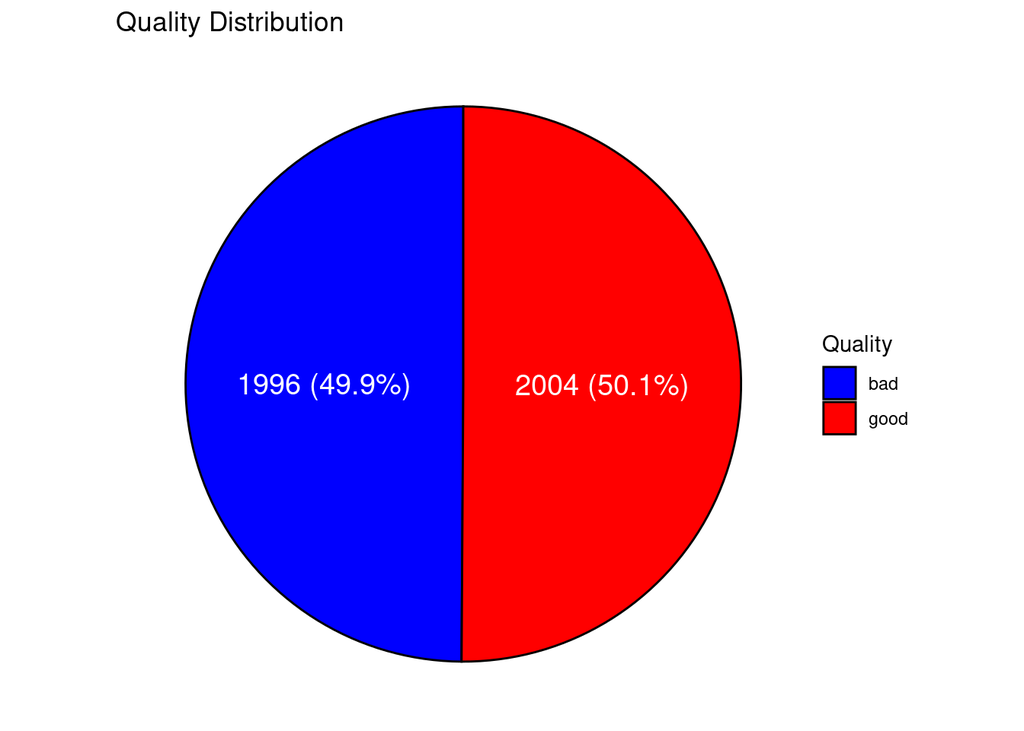

```r
library(dplyr)
library(ggplot2)

# Create a table of counts
quality_counts <- table(apple_quality$Quality)

# Convert to a data frame
quality_counts_df <- as.data.frame(quality_counts) %>%
  rename(Quality = Var1, Count = Freq) %>%  # Rename columns properly
  mutate(Percentage = round(Count / sum(Count) * 100, 1),  # Calculate percentages
         Label = paste0(Count, " (", Percentage, "%)"))   # Create label with count & percentage

# Create a pie chart with labels
ggplot(quality_counts_df, aes(x = "", y = Count, fill = factor(Quality))) +
  geom_bar(stat = "identity", width = 1, color = "black") +  # Create bar chart
  coord_polar(theta = "y") +  # Convert to pie chart
  scale_fill_manual(values = c("good" = "red", "bad" = "blue")) +  # Custom colors
  labs(title = "Quality Distribution", fill = "Quality") +
  theme_void() +  # Remove background grid and axes
  geom_text(aes(label = Label), position = position_stack(vjust = 0.5), size = 5, color = "white")
```

```r
apple_quality$Quality <- ifelse(apple_quality$Quality == "good", 1, 0)
```

Analysing the distribution of each features.

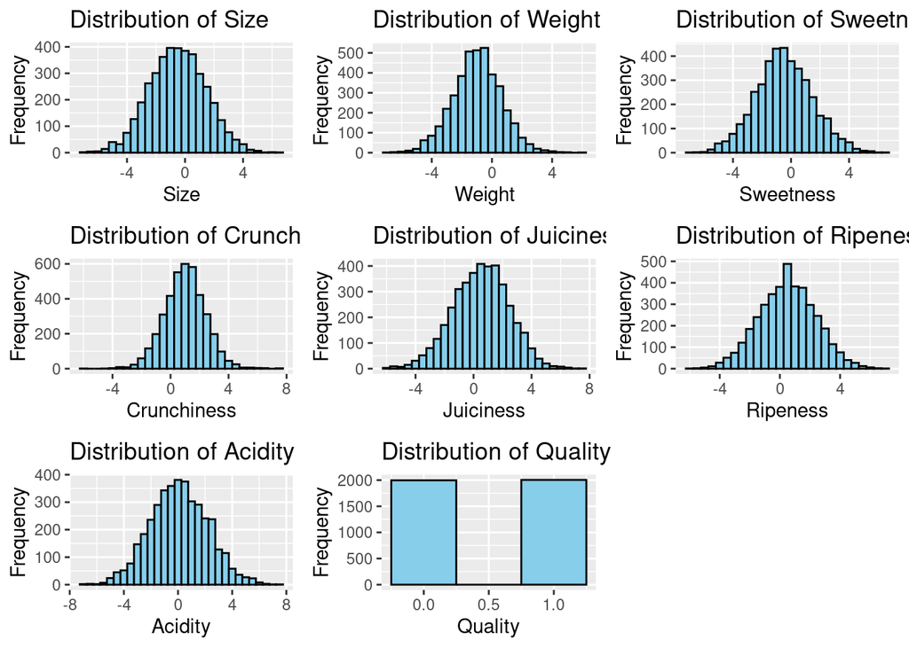

```r
plots_list <- list()

plot_distribution <- function(data, col_name) {
  if(is.numeric(data[[col_name]])) {
    ggplot(data, aes(x = !!sym(col_name))) +
      geom_histogram(binwidth = 0.5, fill = "skyblue", color = "black") +
      labs(title = paste("Distribution of", col_name),
           x = col_name,
           y = "Frequency")
  } else {
    ggplot(data, aes(x = factor(!!sym(col_name)))) +
      geom_bar(fill = "skyblue", color = "black") +
      labs(title = paste("Distribution of", col_name),
           x = col_name,
           y = "Frequency")
  }
}

for (col_name in names(apple_quality)) {
  plots_list[[col_name]] <- plot_distribution(apple_quality, col_name)
}

grid.arrange(grobs = plots_list, ncol = 3)
```

Plotting correlation matrix for all numeric columns in our data set.

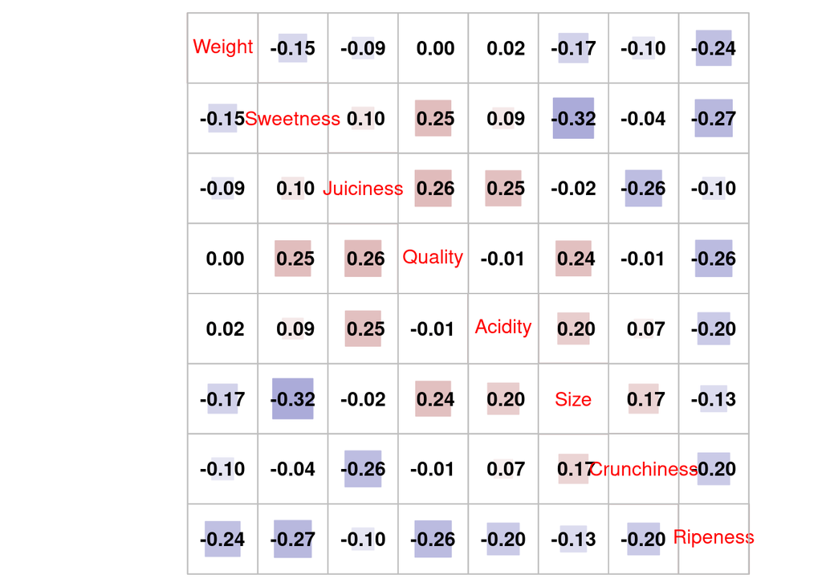

```r
correlation_matrix <- cor(apple_quality)
corrplot(correlation_matrix, method = 'square', order = 'AOE', addCoef.col = 'black',
         tl.pos = 'd', cl.pos = 'n',
         col = colorRampPalette(c("darkblue", "white", "darkred"))(200))
```

Finding the outliers

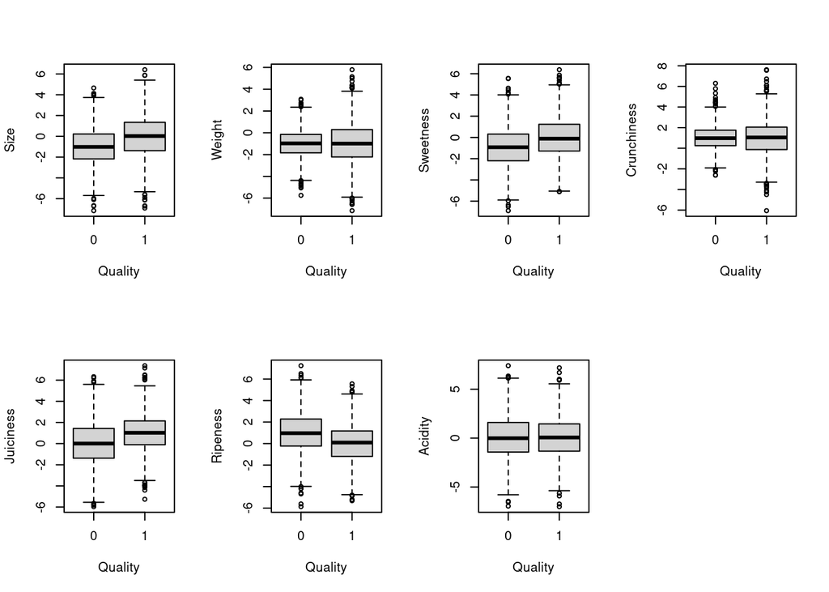

```r
par(mfrow = c(2, 4))
for (col in colnames(apple_quality)) {
  if (col == 'Quality') next
  boxplot(as.formula(paste(col, '~Quality')), data=apple_quality)
}
```

```r
str(apple_quality)
```

```
## 'data.frame':    4000 obs. of  8 variables:
##  $ Size       : num  -3.97 -1.195 -0.292 -0.657 1.364 ...
##  $ Weight     : num  -2.51 -2.84 -1.35 -2.27 -1.3 ...
##  $ Sweetness  : num  5.346 3.664 -1.738 1.325 -0.385 ...
##  $ Crunchiness: num  -1.012 1.5882 -0.3426 -0.0979 -0.553 ...
##  $ Juiciness  : num  1.845 0.853 2.839 3.638 3.031 ...
##  $ Ripeness   : num  0.33 0.868 -0.038 -3.414 -1.304 ...
##  $ Acidity    : num  -0.492 -0.723 2.622 0.791 0.502 ...
##  $ Quality    : num  1 1 0 1 1 0 1 1 0 0 ...
```

## 5. Modelling

Let us separate the feature and target variables in our data set. We know that the Quality is our target variable.

```r
target_variable <- apple_quality[, ncol(apple_quality)]
cat("Shape of target_variable: ", length(target_variable), "\n")
```

```
## Shape of target_variable:  4000
```

```r
feature_variables <- apple_quality[, -ncol(apple_quality)]

shape_feature_variables <- dim(feature_variables)
cat("Shape of feature_variables:", shape_feature_variables, "\n")
```

```
## Shape of feature_variables: 4000 7
```

```r
target_variable <- as.factor(target_variable)
apple_quality[, ncol(apple_quality)] <- target_variable
```

Splitting the data set into training and test set is an important step for applying out learning models.

```r
# Load necessary library
library(caret)

# Set seed for reproducibility
SEED <- 42
set.seed(SEED)

# Assume X and y are predefined (features and target variable)
# Splitting data into 80% train and 20% test
train_index <- createDataPartition(target_variable, p = 0.8, list = FALSE)
X_train <- feature_variables[train_index, ]
y_train <- target_variable[train_index]
X_test <- feature_variables[-train_index, ]
y_test <- target_variable[-train_index]

# Splitting the train set into 80% train and 20% validation
train_index_val <- createDataPartition(y_train, p = 0.8, list = FALSE)
X_train_final <- X_train[train_index_val, ]
y_train_final <- y_train[train_index_val]
X_val <- X_train[-train_index_val, ]
y_val <- y_train[-train_index_val]

# Print dataset shapes
cat("X_train shape: ", dim(X_train_final), "\n")
```

```
## X_train shape:  2562 7
```

```r
cat("X_val shape: ", dim(X_val), "\n")
```

```
## X_val shape:  639 7
```

```r
cat("X_test shape: ", dim(X_test), "\n")
```

```
## X_test shape:  799 7
```

```r
# Print target variable distribution
cat("\nY train value counts:\n")
```

```
##
## Y train value counts:
```

```r
print(table(y_train_final))
```

```
## y_train_final
##    0    1
## 1278 1284
```

```r
cat('----------------\n')
cat("Y validation value counts:\n")
```

```
## Y validation value counts:
```

```r
print(table(y_val))
```

```
## y_val
##   0   1
## 319 320
```

```r
cat('----------------\n')
cat("Y test value counts:\n")
```

```
## Y test value counts:
```

```r
print(table(y_test))
```

```
## y_test
##   0   1
## 399 400
```

```r
cat('----------------\n')
```

##BASELINE MODEL

```r
# Load necessary libraries
library(caret)
library(ggplot2)
library(pROC)  # For ROC curve

# Set seed for reproducibility
SEED <- 42
set.seed(SEED)

# Assume apple_quality is predefined and contains features & target variable
target_variable <- as.factor(apple_quality[, ncol(apple_quality)])  # Ensure target is a factor
feature_variables <- apple_quality[, -ncol(apple_quality)]  # Extract features

# Split data into 80% train and 20% test
train_index <- createDataPartition(target_variable, p = 0.8, list = FALSE)
train_data <- apple_quality[train_index, ]
test_data <- apple_quality[-train_index, ]

# Further split train data into 80% train and 20% validation
train_index_val <- createDataPartition(train_data$Quality, p = 0.8, list = FALSE)
val_data <- train_data[-train_index_val, ]  # Validation set
train_data <- train_data[train_index_val, ]  # Updated train set

# Print dataset shapes
cat("Train Data Shape: ", dim(train_data), "\n")
```

```
## Train Data Shape:  2562 8
```

```r
cat("Validation Data Shape: ", dim(val_data), "\n")
```

```
## Validation Data Shape:  639 8
```

```r
cat("Test Data Shape: ", dim(test_data), "\n")
```

```
## Test Data Shape:  799 8
```

```r
# Print target variable distribution
cat("\nTrain Data Class Distribution:\n")
```

```
##
## Train Data Class Distribution:
```

```r
print(table(train_data$Quality))
```

```
##
##    0    1
## 1278 1284
```

```r
cat("----------------\n")
cat("Validation Data Class Distribution:\n")
```

```
## Validation Data Class Distribution:
```

```r
print(table(val_data$Quality))
```

```
##
##   0   1
## 319 320
```

```r
cat("----------------\n")
cat("Test Data Class Distribution:\n")
```

```
## Test Data Class Distribution:
```

```r
print(table(test_data$Quality))
```

```
##
##   0   1
## 399 400
```

```r
cat("----------------\n")
```

```r
# Ensure the target variable is a factor
train_data$Quality <- as.factor(train_data$Quality)
test_data$Quality <- as.factor(test_data$Quality)

# Define cross-validation control
train_control <- trainControl(method = "cv", number = 10)  # 10-fold CV

# Train KNN model with tuning over k = 1 to 10
knn_results <- train(Quality ~ .,
                     data = train_data,
                     method = "knn",
                     trControl = train_control,
                     preProcess = "scale",  # Standardize features
                     tuneGrid = expand.grid(k = 1:10))

# Extract results (accuracies and k values)
results <- knn_results$results
plot_data <- data.frame(k = results$k, Accuracy = results$Accuracy)

# Print accuracies for each k
print(plot_data)
```

```
##     k  Accuracy
## 1   1 0.8649497
## 2   2 0.8661018
## 3   3 0.8805656
## 4   4 0.8778404
## 5   5 0.8860192
## 6   6 0.8879708
## 7   7 0.8906976
## 8   8 0.8868005
## 9   9 0.8907082
## 10 10 0.8903069
```

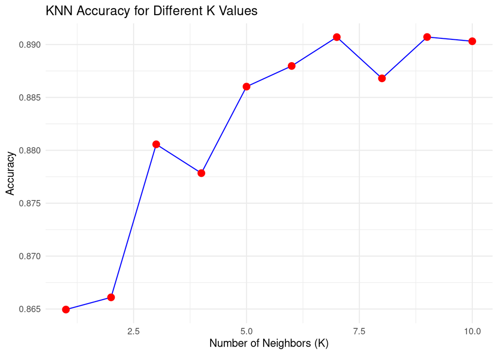

```r
# Plot accuracy vs. k
ggplot(plot_data, aes(x = k, y = Accuracy)) +
  geom_line(color = "blue") +
  geom_point(color = "red", size = 3) +
  labs(title = "KNN Accuracy for Different K Values",
       x = "Number of Neighbors (K)",
       y = "Accuracy") +
  theme_minimal()
```

```r
# Train final KNN model using k = 7
knn_model <- train(Quality ~ .,
                   data = train_data,
                   method = "knn",
                   trControl = train_control,
                   preProcess = "scale",  # Ensure features are scaled
                   tuneGrid = data.frame(k = 7))  # Using k = 7

# Make predictions on test data
predictions <- predict(knn_model, newdata = test_data)
accuracy <- mean(predictions == test_data$Quality)  # Compute accuracy

cat("Accuracy of the KNN model with k=7: ", round(accuracy * 100, 2), "%\n")
```

```
## Accuracy of the KNN model with k=7:  89.24 %
```

```r
# Compute confusion matrix
conf_matrix <- table(Predicted = predictions, Actual = test_data$Quality)
print(conf_matrix)
```

```
##          Actual
## Predicted   0   1
##         0 355  42
##         1  44 358
```

```r
# Compute Precision, Recall, and F1-Score
tp <- sum(predictions == test_data$Quality & test_data$Quality == levels(test_data$Quality)[2])  # True Positives
fp <- sum(predictions != test_data$Quality & predictions == levels(test_data$Quality)[2])  # False Positives
fn <- sum(predictions != test_data$Quality & test_data$Quality == levels(test_data$Quality)[2])  # False Negatives

precision <- ifelse(tp + fp == 0, 0, tp / (tp + fp))
recall <- ifelse(tp + fn == 0, 0, tp / (tp + fn))
f1_score <- ifelse(precision + recall == 0, 0, 2 * (precision * recall) / (precision + recall))

cat("Precision:", round(precision, 4), "\n")
```

```
## Precision: 0.8905
```

```r
cat("Recall:", round(recall, 4), "\n")
```

```
## Recall: 0.895
```

```r
cat("F1 Score:", round(f1_score, 4), "\n")
```

```
## F1 Score: 0.8928
```

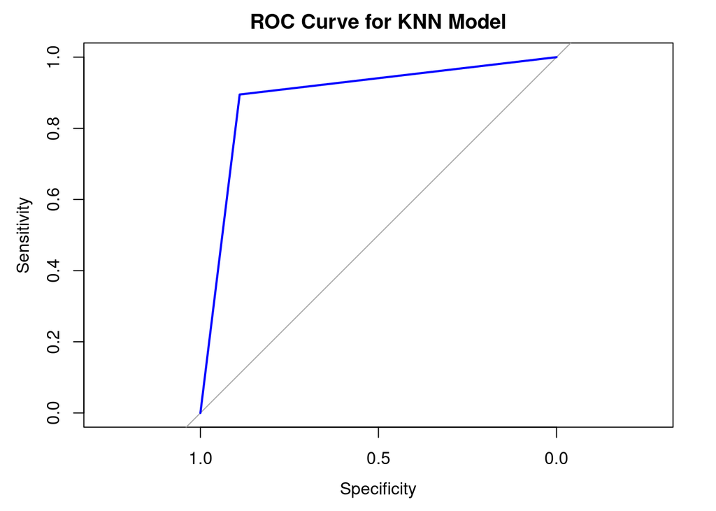

```r
# Compute and plot ROC curve
roc_curve <- roc(test_data$Quality, as.numeric(predictions))
plot(roc_curve, main = "ROC Curve for KNN Model", col = "blue", lwd = 2)
```

KNN performs very well with the accuracy of 88 to 90% on our test_data

```r
library(caret)

# Set up training control for cross-validation
train_control <- trainControl(method = "cv", number = 5)

# Initialize the classifiers list
classifiers <- list()

# Logistic Regression
set.seed(42)
logit_model <- train(Quality ~ ., data = train_data, method = "glm",
                     family = "binomial",  # Logistic Regression
                     trControl = train_control,
                     preProcess = c("center", "scale"))
classifiers[["Logistic Regression"]] <- logit_model

# Support Vector Machine (SVM)
set.seed(42)
svm_model <- train(Quality ~ ., data = train_data, method = "svmRadial",
                   trControl = train_control,
                   preProcess = c("center", "scale"),
                   tuneLength = 5)
classifiers[["SVM"]] <- svm_model

# Decision Tree
set.seed(42)
dt_model <- train(Quality ~ ., data = train_data, method = "rpart",
                  trControl = train_control,
                  preProcess = c("center", "scale"))
classifiers[["Decision Tree"]] <- dt_model

# Random Forest
set.seed(42)
rf_model <- train(Quality ~ ., data = train_data, method = "rf",
                  trControl = train_control,
                  preProcess = c("center", "scale"),
                  tuneLength = 5)
classifiers[["Random Forest"]] <- rf_model

cat("✅ All models trained and stored in the 'classifiers' list.\n")
```

```
## ✅ All models trained and stored in the 'classifiers' list.
```

```r
library(caret)

# Check if classifiers exist
if (!exists("classifiers") || length(classifiers) == 0) {
  stop("Error: The 'classifiers' object is not found. Train models and store them in the 'classifiers' list before running this script.")
}

# Initialize empty data frames
sorted_classifiers <- data.frame(Model = character(), Accuracy = numeric(), F1_Score = numeric(), stringsAsFactors = FALSE)
test_sorted_classifiers <- data.frame(Model = character(), Test_Accuracy = numeric(), Test_F1_Score = numeric(), stringsAsFactors = FALSE)

for (model_name in names(classifiers)) {
  model <- classifiers[[model_name]]

  #  Predict on validation set
  y_val_pred <- predict(model, newdata = val_data)
  val_accuracy <- mean(y_val_pred == val_data$Quality)

  #  Compute F1-score for validation set
  val_conf_matrix <- confusionMatrix(as.factor(y_val_pred), as.factor(val_data$Quality))
  val_f1_score <- ifelse(!is.null(val_conf_matrix$byClass["F1"]),
                         val_conf_matrix$byClass["F1"],
                         mean(val_conf_matrix$byClass[, "F1"]))  # Handle multiple classes

  cat("\n----------------", model_name, "----------------\n")
  cat("Validation Accuracy:", round(val_accuracy, 3), "\n")
  cat("Validation F1-Score:", round(val_f1_score, 3), "\n")

  # Store validation results
  sorted_classifiers <- rbind(sorted_classifiers, data.frame(Model = model_name, Accuracy = val_accuracy, F1_Score = val_f1_score))

  # Predict on test set
  y_test_pred <- predict(model, newdata = test_data)
  test_accuracy <- mean(y_test_pred == test_data$Quality)

  #  Compute F1-score for test set
  test_conf_matrix <- confusionMatrix(as.factor(y_test_pred), as.factor(test_data$Quality))
  test_f1_score <- ifelse(!is.null(test_conf_matrix$byClass["F1"]),
                          test_conf_matrix$byClass["F1"],
                          mean(test_conf_matrix$byClass[, "F1"]))  # Handle multiple classes

  cat("Test Accuracy:", round(test_accuracy, 3), "\n")
  cat("Test F1-Score:", round(test_f1_score, 3), "\n")

  # Store test results
  test_sorted_classifiers <- rbind(test_sorted_classifiers, data.frame(Model = model_name, Test_Accuracy = test_accuracy, Test_F1_Score = test_f1_score))
}
```

```
##
## ---------------- Logistic Regression ----------------
## Validation Accuracy: 0.748
## Validation F1-Score: 0.745
## Test Accuracy: 0.726
## Test F1-Score: 0.72
##
## ---------------- SVM ----------------
## Validation Accuracy: 0.895
## Validation F1-Score: 0.893
## Test Accuracy: 0.904
## Test F1-Score: 0.903
##
## ---------------- Decision Tree ----------------
## Validation Accuracy: 0.676
## Validation F1-Score: 0.657
## Test Accuracy: 0.672
## Test F1-Score: 0.656
##
## ---------------- Random Forest ----------------
## Validation Accuracy: 0.878
## Validation F1-Score: 0.874
## Test Accuracy: 0.87
## Test F1-Score: 0.867
```

```r
# Sort classifiers by validation accuracy
sorted_classifiers <- sorted_classifiers[order(-sorted_classifiers$Accuracy), ]
cat("\n🔹 Sorted Classifiers by Validation Accuracy:\n")
```

```
##
## 🔹 Sorted Classifiers by Validation Accuracy:
```

```r
print(sorted_classifiers)
```

```
##                 Model  Accuracy  F1_Score
## 2                 SVM 0.8951487 0.8934817
## 4       Random Forest 0.8779343 0.8737864
## 1 Logistic Regression 0.7480438 0.7448494
## 3       Decision Tree 0.6760563 0.6567164
```

```r
#  Sort classifiers by test accuracy
test_sorted_classifiers <- test_sorted_classifiers[order(-test_sorted_classifiers$Test_Accuracy), ]
cat("\n🔹 Sorted Classifiers by Test Accuracy:\n")
```

```
##
## 🔹 Sorted Classifiers by Test Accuracy:
```

```r
print(test_sorted_classifiers)
```

```
##                 Model Test_Accuracy Test_F1_Score
## 2                 SVM     0.9036295     0.9031447
## 4       Random Forest     0.8698373     0.8673469
## 1 Logistic Regression     0.7259074     0.7195903
## 3       Decision Tree     0.6720901     0.6561680
```

##MULTIPLE CLASSIFIERS MODEL BUILDING Four different classifier such as logisitic regression,Decision tree,Random forest and SVM were used to see the model performance in various aspects accuracy and F1 score were taken as evaluation metrics.

## SVM Hyperparameter tuning

```r
# Load required libraries
library(caret)
library(e1071)

# Set seed for reproducibility
set.seed(42)

# Define parameter grid for 'C' and 'sigma' hyperparameter tuning
param_grid <- expand.grid(
  C = c(0.1, 1, 10, 100),  # Cost parameter
  sigma = c(0.1, 0.5, 1, 2)  # Sigma values for the RBF kernel
)

# Train an SVM model with cross-validation and tune hyperparameters 'C' and 'sigma'
svm_tune <- train(Quality ~ ., data = data.frame(X_train, Quality = y_train),
                  method = "svmRadial",
                  trControl = trainControl(method = "cv", number = 5),
                  tuneGrid = param_grid,
                  preProcess = c("center", "scale"))

# Best model and parameters
cat("Best C Value:", svm_tune$bestTune$C, "\n")
```

```
## Best C Value: 1
```

```r
cat("Best Sigma Value:", svm_tune$bestTune$sigma, "\n")
```

```
## Best Sigma Value: 0.5
```

```r
cat("Best Model Accuracy (Training):", svm_tune$results$Accuracy[which.min(svm_tune$results$Resample)], "\n")
```

```
## Best Model Accuracy (Training):
```

```r
# Predict on test set using the best model
y_test_pred <- predict(svm_tune, newdata = data.frame(X_test))

# Calculate accuracy
test_accuracy <- mean(y_test_pred == y_test)
cat("Test Accuracy:", round(test_accuracy, 3), "\n")
```

```
## Test Accuracy: 0.919
```

```r
# Generate confusion matrix
conf_matrix <- confusionMatrix(as.factor(y_test_pred), as.factor(y_test))
print(conf_matrix)
```

```
## Confusion Matrix and Statistics
##
##           Reference
## Prediction   0   1
##          0 369  35
##          1  30 365
##
##                Accuracy : 0.9186
##                  95% CI : (0.8975, 0.9367)
##     No Information Rate : 0.5006
##     P-Value [Acc > NIR] : <2e-16
##
##                   Kappa : 0.8373
##
##  Mcnemar's Test P-Value : 0.6198
##
##             Sensitivity : 0.9248
##             Specificity : 0.9125
##          Pos Pred Value : 0.9134
##          Neg Pred Value : 0.9241
##              Prevalence : 0.4994
##          Detection Rate : 0.4618
##    Detection Prevalence : 0.5056
##       Balanced Accuracy : 0.9187
##
##        'Positive' Class : 0
##
```

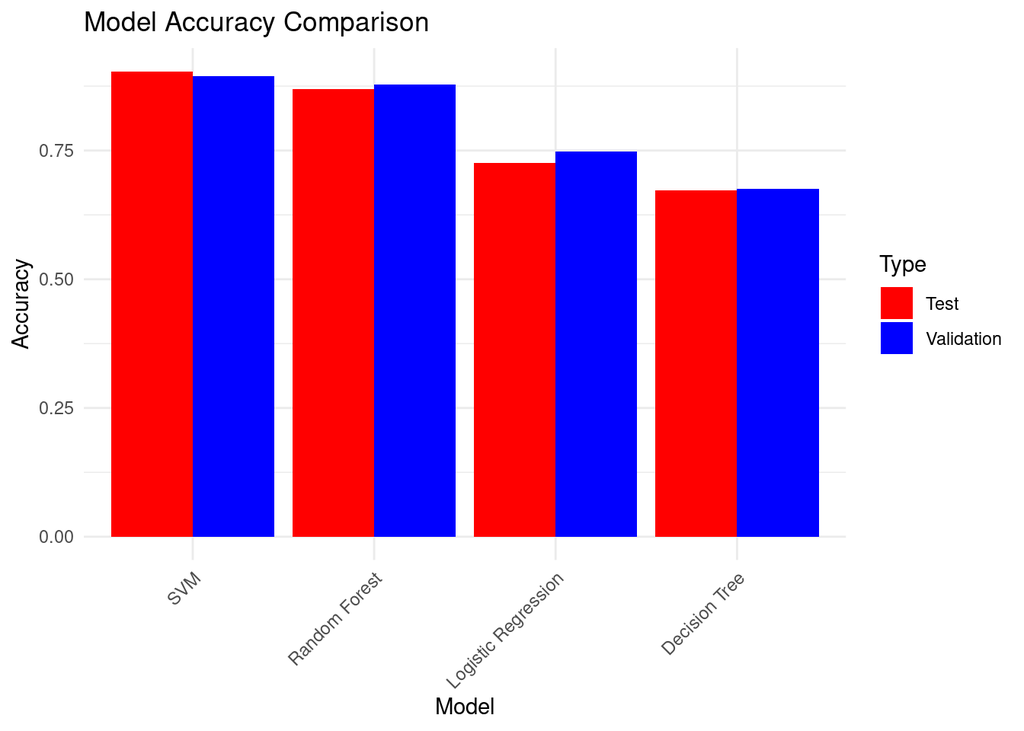

```r
library(ggplot2)

# Ensure both data frames have the same column names
colnames(test_sorted_classifiers) <- colnames(sorted_classifiers)

# Add a column to distinguish Validation vs Test
sorted_classifiers$Type <- "Validation"
test_sorted_classifiers$Type <- "Test"

# Combine both data frames
accuracy_data <- rbind(sorted_classifiers, test_sorted_classifiers)

# Plot the bar chart
ggplot(accuracy_data, aes(x = reorder(Model, -Accuracy), y = Accuracy, fill = Type)) +
  geom_bar(stat = "identity", position = "dodge") +
  labs(title = "Model Accuracy Comparison", x = "Model", y = "Accuracy") +
  theme_minimal() +
  theme(axis.text.x = element_text(angle = 45, hjust = 1)) +
  scale_fill_manual(values = c("Validation" = "blue", "Test" = "red"))
```

## ROC CURVE

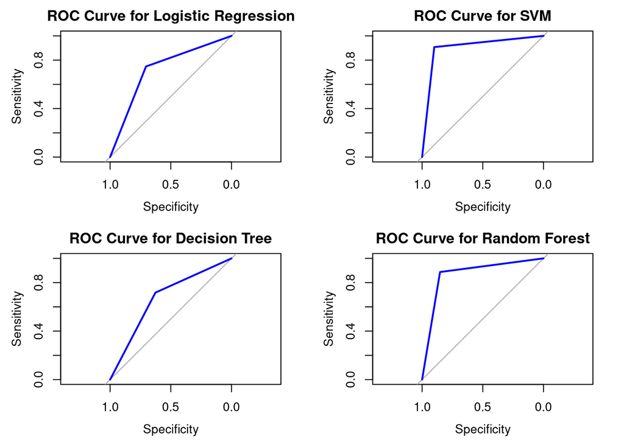

```r
library(pROC)

# Set up a 2x2 grid for subplots (adjust based on number of models)
par(mfrow = c(2, 2))

# Loop through models and plot ROC curves in separate subplots
for (model_name in names(classifiers)) {
  model <- classifiers[[model_name]]

  # Get probabilities or convert labels to numeric
  if ("prob" %in% names(predict(model, X_test, type = "raw"))) {
    y_test_prob <- predict(model, X_test, type = "prob")[, 2]  # Probability for class 1
  } else {
    y_test_prob <- as.numeric(predict(model, X_test))  # Convert class labels to numeric
  }

  # Convert y_test to numeric (0/1)
  y_test_numeric <- as.numeric(as.factor(y_test)) - 1

  # Compute ROC
  roc_curve <- roc(y_test_numeric, y_test_prob)

  # Plot ROC Curve
  plot(roc_curve, col = "blue", main = paste("ROC Curve for", model_name), lwd = 2)
  #abline(a = 0, b = 1, col = "gray", lty = 2)  # Diagonal baseline
}
```

To summarize, The binary classification approach to some extend provides decent assessments.The chosen metrics, including accuracy, confusion matrix, F1 score, ROC curves, offered a comprehensive evaluation of model performance.The ROC curves provided insights into the models’ discriminatory abilities.We can see SVM performs well with better Accuracy and F1 score.The evaluation metrics and sensitivity analysis are based on a specific threshold.